# Introduction

- What complaints happened every day?
- Which hour had the most requests?
- Which requests happened after hours?

# Setup

```python
%matplotlib inline
%autosave 15
import numpy as np
import matplotlib.pyplot as plt
import pandas as pd
import seaborn as sns
sns.set()

import warnings
import matplotlib.cbook
warnings.filterwarnings("ignore",category=matplotlib.cbook.mplDeprecation)
```

```
Autosaving every 15 seconds
```

```python
entry = pd.read_csv("Datasets/Service_Requests_311.csv")
```

```python
entry.dtypes
```

```
X                             float64
Y                             float64
OBJECTID                        int64
DEPARTMENT                     object
DIVISION                       object
REQUEST_NO                      int64
FISCAL_YEAR                     int64
FISCAL_MONTH                   object
REQUEST_TYPE                   object
RECEIVED_DATE                  object
INTERNAL_FIELD_OBSERVATION     object
TITLE                          object
CMPD_DIVISION                  object
NEIGHBORHOOD_PROFILE_AREA     float64
BLOCK_NO                      float64
STREET_DIRECTION               object
STREET_NAME                    object
STREET_TYPE                    object
CITY                           object
STATE                          object
ZIP_CODE                      float64
FULL_ADDRESS                   object
X_COORD                       float64
Y_COORD                       float64
LATITUDE                      float64
LONGITUDE                     float64
COUNCIL_DISTRICT              float64
GlobalID                       object
dtype: object
```

# Cleaning the Data

```python
calls = entry[['DEPARTMENT','DIVISION','REQUEST_TYPE', 'RECEIVED_DATE','CITY','ZIP_CODE','X_COORD','Y_COORD', 'LATITUDE',
              'LONGITUDE']]
```

## Dropping null values

```python
calls = calls.dropna()
```

```python
calls = calls.sort_values(by=['RECEIVED_DATE'])
```

## Converting dates to datetime

```python
calls['RECEIVED_DATE']= pd.to_datetime(calls['RECEIVED_DATE'])
```

```python
calls = calls.sort_values(by=['RECEIVED_DATE'])
```

```python
calls = calls[(calls.RECEIVED_DATE.dt.year == 2018)]#&(calls.RECEIVED_DATE.dt.month == 12)]
```

```python
calls['Day'] = calls['RECEIVED_DATE'].dt.day
calls['Hour'] = calls['RECEIVED_DATE'].dt.hour
calls['Day_Week'] = calls['RECEIVED_DATE'].dt.weekday
```

```python
calls.head()
```

|  | DEPARTMENT | DIVISION | REQUEST_TYPE | RECEIVED_DATE | CITY | ZIP_CODE | X_COORD | Y_COORD | LATITUDE | LONGITUDE | Day | Hour | Day_Week |
| --- | --- | --- | --- | --- | --- | --- | --- | --- | --- | --- | --- | --- | --- |
| 241174 | Solid Waste Services | Sanitation | NON_RECYCLABLE ITEMS | 2018-01-01 00:11:32+00:00 | CHARLOTTE | 28205.0 | 1475001.0 | 542077.0 | 35.226683 | -80.758088 | 1 | 0 | 0 |
| 194234 | Solid Waste Services | Sanitation | NON_RECYCLABLE ITEMS | 2018-01-01 00:21:52+00:00 | CHARLOTTE | 28210.0 | 1444432.0 | 505880.0 | 35.125712 | -80.858164 | 1 | 0 | 0 |
| 243683 | Solid Waste Services | Sanitation | NON_RECYCLABLE ITEMS | 2018-01-01 00:27:07+00:00 | CHARLOTTE | 28226.0 | 1440864.0 | 490514.0 | 35.083314 | -80.869127 | 1 | 0 | 0 |
| 740170 | Solid Waste Services | Sanitation | RECYCLABLE ITEMS | 2018-01-01 01:18:18+00:00 | CHARLOTTE | 28273.0 | 1415789.0 | 514157.0 | 35.146939 | -80.954484 | 1 | 1 | 0 |
| 243684 | Solid Waste Services | Sanitation | NON_RECYCLABLE ITEMS | 2018-01-01 01:18:19+00:00 | CHARLOTTE | 28273.0 | 1415789.0 | 514157.0 | 35.146939 | -80.954484 | 1 | 1 | 0 |

# Exploring the Data

## 1. How many requests do we have?

The function `howManyRequests` retursn the number of 311 requests that were made.

```python
def howManyRequests(calls):
    ''' Return the number of requests, N'''
    return calls.shape[0]
print('Number of requests =', howManyRequests(calls))
```

```
Number of requests = 298709
```

## 2. What was the average number of requests per hour?

The function `averageNumberRequestsPerHour` returns the average number of requests per hour.

```python
def averageNumberRequestsPerHour(calls):
    ''' Return the average number of requests per hour '''
    per_hour = ((calls.loc[calls.index[-1],'Hour']+1)*(calls.loc[calls.index[-1],'Day']+1))
    return (howManyRequests(calls))/per_hour

print('Average requests per hour', averageNumberRequestsPerHour(calls))
```

```
Average requests per hour 388.9440104166667
```

## 3. Which cities are in the data?

```python
def cityLocations(calls):
    ''' Return a NumPy array of the alphabetized list of the different values
    in the city column of the locations.  Each city name should be in the list
    only once.'''
    return (calls.CITY.unique())

print('Cities =', cityLocations(calls))
```

```
Cities = ['CHARLOTTE' 'MATTHEWS' 'HUNTERSVILLE' 'MINT HILL' 'CORNELIUS' 'DAVIDSON'
 'PINEVILLE']
```

## 4. Which complaints happened every day?

- The function `complaintsEachDay` returns an alphabetical NumPy array of complaints that occur every day in the data.
- In other words, if there is even a single day without a particular complaint, that complaint will not be returned.

```python
def compaintsEachDay(calls):
    ''' Return an alphabetical list of complaints that occur every day in the data'''
    div = list(calls.REQUEST_TYPE.unique())
    for day in range(np.max(calls.Day)+1):
        for x in div:
            if x not in calls.loc[calls['Day'] == day, 'REQUEST_TYPE'].unique():
                div.remove(x)
    return(sorted(div))


print('Complaints that happened every day', compaintsEachDay(calls))
```

[output not shown]

## 5. Which time had the most requests?

The function `dayHourTime` returns a two-element array of the day and hour of the time that had the most requests.

```python
def dayHourTime(calls):
    ''' Return a NumPy array where the first element is the day and the second element is the hour
    that had the most requests'''
    arr = np.array(calls[['Day','Hour']].value_counts().index[0])
    return(arr)


A5 = dayHourTime(calls)
print('Most requests happened on day', A5[0], 'hour', A5[1])
```

```
Most requests happened on day 5 hour 14
```

[figure not shown]

```python
df = calls[(calls.Day==3)&(calls.Hour==A5[1])]
counts = df.DEPARTMENT.value_counts()
unique = df.DEPARTMENT.unique()

ax = sns.barplot(x = unique ,y = counts, data=df)
ax.set_xticklabels(ax.get_xticklabels(), rotation=30)
ax.set_yscale('log')
ax.set(xlabel='Department', ylabel='# Of Requests')
ax.set_title('Distribution of 311 requests on December 3rd, 2018 at 3PM in Charlotte')
plt.show()
```

[figure not shown]

```python
clt = df[(df.CITY=='CHARLOTTE')&(df.DEPARTMENT=='Solid Waste Services')]
counts1 = clt.DIVISION.value_counts()
unique1 = clt.DIVISION.unique()
counts2 = np.log(counts1)


ax = sns.barplot(x = unique1 ,y = counts1, data=clt)
ax.set_xticklabels(ax.get_xticklabels(), rotation=30)
ax.set_yscale('log')
ax.set(xlabel='Division', ylabel='# Of Requests')
ax.set_title('Distribution of Solid Waste Services 311 requests on December 3rd, 2018 at 3PM in Charlotte')
plt.show()
```

## 6. Which division takes the department's most calls?

The function `whichdiv` that returns the division which has the most requests with specified department.

```python
calls['DEPARTMENT'].unique()
```

```
array(['Solid Waste Services', 'Housing and NBHD Serv', 'Transportation',
       'Storm Water Services', 'Mecklenburg County', 'UT-Utilities',
       'City Manager', 'Eng & Prop Mgmt/City', 'Police', 'Transit',
       'Planning/City', 'Management & Fin Services', 'Shared Services'],
      dtype=object)
```

```python
def whichdiv(department, calls):
    ''' Return the division that had the most complaints in department '''
    div_max = calls.loc[calls.DEPARTMENT == department, 'DIVISION'].value_counts().index[0]
    return(div_max)

Dept = 'Police'
print('Division with most requests in Solid Waste Services is', whichdiv(Dept,calls))
```

[output not shown]

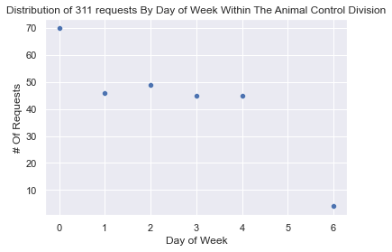

```python
san = calls[calls['DIVISION']==whichdiv(Dept,calls)]

c = san['Day_Week'].value_counts().reset_index()

ax = sns.scatterplot(x = c['index'] ,y = c['Day_Week'])
ax.set(xlabel='Day of Week', ylabel='# Of Requests')
ax.set_title('Distribution of 311 requests By Day of Week Within The '+ whichdiv(Dept,calls)+' Division')
plt.show()
```

It appears that the number of requests is the highest on Mondays and drastically drops between Friday and Saturday.

## 7. Where are they in need of 311 Documents in Pineville?

Plots the points at the coordinates of the requests with city and complaint.

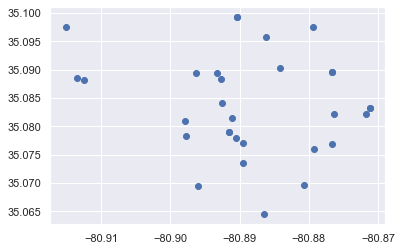

```python
def graphPineville311(city, complaint, calls):
    """
    Plot points at the coordinates of the requests with city and complaint.
    """
    coord = calls[(calls.REQUEST_TYPE == complaint)&(calls.CITY == city)]


    plt.plot(coord['LONGITUDE'], coord['LATITUDE'],'o')

city='PINEVILLE'
complaint='311 DOCUMENT'
A7_plot = graphPineville311(city,complaint,calls)
```

## 8. How long can I sleep?

The function `longestTimeWithNoRequests` returns the length of the longest run of hours with no requests having the complaint string anywhere in the complaint.

```python
def longestTimeWithNoRequests(word, calls):
    ''' Return the number of hours with no requests having the parameter
    request string anywhere in the request. '''
    max_hours = []
    for x in calls.REQUEST_TYPE:
        if word in x:
            max_hours.append(True)
        else:
            max_hours.append(False)

    return (np.diff(calls.Hour[max_hours]).max()-1)

Word = 'RECYCL' # anywhere in the Complaint
print('Longest run of quiet is', longestTimeWithNoRequests(Word, calls), 'hours.')
```

```
Longest run of quiet is 9 hours.
```